# Module Nine Project

For the module nine project you are required to produce coding samples in accordance with the requirements in the project guidelines and rubric. This Notebook has been pre-created as a shell for your project submission.

Once your code is complete, you will download this notebook as an HTML file by clicking **File**, then **Download As**, then **HTML (.html)** from the Jupyter menu bar. Validate that your code and outputs are rendered in the html file before submission.

*Missing Blocks:* Ensure that you have clicked **Run** for all blocks before downloading as an HTML file or the block may be missing from your submission.

### Data Source Information

Below are some example reputable data sources that you can use to collect your minimum of two data sets from:

- https://datasetsearch.research.google.com/
- https://www.kaggle.com/datasets
- https://data.gov/
- https://www.census.gov/data.html
- https://www.bls.gov/data/
- https://databank.worldbank.org/databases
- https://www.ncei.noaa.gov/access/search/index
- https://www.epa.gov/data
- https://www.pewresearch.org/tools-and-datasets/
- https://www.who.int/data/
- https://dataverse.harvard.edu/
- https://search.cdc.gov/search/?query=dataset&dpage=1
- https://data.fivethirtyeight.com/
- https://www.gdeltproject.org/data.html
- https://datahub.io/collections

***Note: this list is not all inclusive, if you have a reputable data set that you have collected, or would like to use, please ensure to upload the data. All data sets will need to be documented in your submission as to the source through the creation of a citation.***

*To Begin:* replace each **data_file_#** entry sample data path with the path to your selected data sets.

You are welcome to use more than two data sets, create an entry for each as applicable for each data set. Ensure that you create comments that provide citations for the data sets you have selected for use. When working through your submission, keep in mind that you will need to have choosen two separate groups of stakeholders to create your final visualizations.

```python
# Dataset 1: California Population Estimates by Age/Race/Ethnicity/Sex
# Source: California Department of Public Health, State of California
# Data.gov dataset: California Population Estimates by Age/Race_Ethnicity/Sex
# at Local Health Jurisdiction Level

data_file_1 = "data/population.csv"

# Dataset 2: Local Area Unemployment Statistics (LAUS), Annual Average
# Source: California Employment Development Department, State of California
# Data.gov dataset: Local Area Unemployment Statistics (LAUS), Annual Average

data_file_2 = "data/unemployment.csv"
```

## Installing Required Packages

If you have additional packages that you would like to use or install, add them to the **requirements.txt** file then run the next two blocks.

```python
!pip install --upgrade pip
```

```python
!pip install -r requirements.txt
```

## Import the Required Packages

```python
import pandas as pd
import matplotlib.pyplot as plt
```

## Loading the Data

Create entries to load your data for your submission.

```python
# Load the two project datasets
population_data = pd.read_csv(data_file_1)
unemployment_data = pd.read_csv(data_file_2)

# Confirm that both datasets loaded successfully
print("Population dataset shape:", population_data.shape)
print("Unemployment dataset shape:", unemployment_data.shape)

print("\nPopulation columns:")
print(population_data.columns.tolist())

print("\nUnemployment columns:")
print(unemployment_data.columns.tolist())
```

```
Population dataset shape: (2761542, 8)
Unemployment dataset shape: (18069, 10)

Population columns:
['county_lhj', 'year', 'sex', 'age', 'race_eth', 'population', 'county_indicator', 'lhj_indicator']

Unemployment columns:
['Area Name', 'Area Type', 'Year', 'Month', 'Seasonally Adjusted(Y/N)', 'Status', 'Labor Force', 'Employment', 'Unemployment', 'Unemployment Rate']
```

## Examining the Data

Create entries to conduct exploratory data analysis to identify key data points to include relevant data from your two data sets while evaluating the quality of your choosen data.

```python
# Examine the population dataset
print("POPULATION DATASET")
print("Shape:", population_data.shape)

display(population_data.head(10))

print("\nPopulation data types:")
print(population_data.dtypes)

print("\nPopulation missing values:")
print(population_data.isnull().sum())


# Examine the unemployment dataset
print("\nUNEMPLOYMENT DATASET")
print("Shape:", unemployment_data.shape)

display(unemployment_data.head(10))

print("\nUnemployment data types:")
print(unemployment_data.dtypes)

print("\nUnemployment missing values:")
print(unemployment_data.isnull().sum())
```

```
POPULATION DATASET
Shape: (2761542, 8)
```

|  | county_lhj | year | sex | age | race_eth | population | county_indicator | lhj_indicator |
| --- | --- | --- | --- | --- | --- | --- | --- | --- |
| 0 | Alameda | 2000 | Female | 0 | AI/AN | 30.818835 | 1 | 0 |
| 1 | Alameda | 2000 | Female | 0 | Asian | 1932.729319 | 1 | 0 |
| 2 | Alameda | 2000 | Female | 0 | Black | 1356.941115 | 1 | 0 |
| 3 | Alameda | 2000 | Female | 0 | Latino | 2956.468872 | 1 | 0 |
| 4 | Alameda | 2000 | Female | 0 | Multi-Race | 641.741462 | 1 | 0 |
| 5 | Alameda | 2000 | Female | 0 | NH/PI | 58.741815 | 1 | 0 |
| 6 | Alameda | 2000 | Female | 0 | White | 2719.749388 | 1 | 0 |
| 7 | Alameda | 2000 | Female | 1 | AI/AN | 36.445635 | 1 | 0 |
| 8 | Alameda | 2000 | Female | 1 | Asian | 1850.013019 | 1 | 0 |
| 9 | Alameda | 2000 | Female | 1 | Black | 1338.081603 | 1 | 0 |

```
Population data types:
county_lhj           object
year                  int64
sex                  object
age                   int64
race_eth             object
population          float64
county_indicator      int64
lhj_indicator         int64
dtype: object

Population missing values:
county_lhj          0
year                0
sex                 0
age                 0
race_eth            0
population          0
county_indicator    0
lhj_indicator       0
dtype: int64

UNEMPLOYMENT DATASET
Shape: (18069, 10)
```

|  | Area Name | Area Type | Year | Month | Seasonally Adjusted(Y/N) | Status | Labor Force | Employment | Unemployment | Unemployment Rate |
| --- | --- | --- | --- | --- | --- | --- | --- | --- | --- | --- |
| 0 | California | State | 1990 | Annual | N | Final | 15176300 | 14301800 | 874500 | 5.8 |
| 1 | California | State | 1991 | Annual | N | Final | 15127400 | 13946700 | 1180800 | 7.8 |
| 2 | California | State | 1992 | Annual | N | Final | 15314800 | 13878500 | 1436200 | 9.4 |
| 3 | California | State | 1993 | Annual | N | Final | 15258800 | 13804100 | 1454700 | 9.5 |
| 4 | California | State | 1994 | Annual | N | Final | 15253900 | 13931900 | 1322000 | 8.7 |
| 5 | California | State | 1995 | Annual | N | Final | 15249600 | 14045200 | 1204400 | 7.9 |
| 6 | California | State | 1996 | Annual | N | Final | 15419500 | 14286400 | 1133100 | 7.3 |
| 7 | California | State | 1997 | Annual | N | Final | 15800900 | 14789600 | 1011300 | 6.4 |
| 8 | California | State | 1998 | Annual | N | Final | 16163200 | 15200600 | 962600 | 6.0 |
| 9 | California | State | 1999 | Annual | N | Final | 16430400 | 15565100 | 865200 | 5.3 |

```
Unemployment data types:
Area Name                    object
Area Type                    object
Year                          int64
Month                        object
Seasonally Adjusted(Y/N)     object
Status                       object
Labor Force                   int64
Employment                    int64
Unemployment                  int64
Unemployment Rate           float64
dtype: object

Unemployment missing values:
Area Name                   0
Area Type                   0
Year                        0
Month                       0
Seasonally Adjusted(Y/N)    0
Status                      0
Labor Force                 0
Employment                  0
Unemployment                0
Unemployment Rate           0
dtype: int64
```

## Data Preprocessing Techniques

Create entries to clean and blend your data sets as applicable consolidating the two or more data sets into a single collection for inclusion into your visualizations.

```python
# Prepare population data for county-level analysis
# Keep county records only and aggregate demographic groups into
# one population total for each county and year.
population_clean = population_data[
    population_data["county_indicator"] == 1
].copy()

population_county = (
    population_clean
    .groupby(["county_lhj", "year"], as_index=False)["population"]
    .sum()
)

# Prepare unemployment data for county-level annual analysis
# Keep annual county records so the geographic and time levels
# match the population dataset.
unemployment_clean = unemployment_data[
    (unemployment_data["Area Type"] == "County") &
    (unemployment_data["Month"] == "Annual")
].copy()

# Standardize county names and column names before blending.
unemployment_clean["county_lhj"] = (
    unemployment_clean["Area Name"]
    .str.replace(" County", "", regex=False)
    .str.strip()
)

unemployment_clean = unemployment_clean.rename(
    columns={"Year": "year"}
)

# Keep only the fields needed for the analysis.
unemployment_county = unemployment_clean[
    [
        "county_lhj",
        "year",
        "Labor Force",
        "Employment",
        "Unemployment",
        "Unemployment Rate"
    ]
].copy()

# Check the prepared datasets.
print("Population county/year shape:", population_county.shape)
print("Unemployment county/year shape:", unemployment_county.shape)

print("\nPopulation sample:")
display(population_county.head())

print("\nUnemployment sample:")
display(unemployment_county.head())

# Blend the population and unemployment datasets
# using county and year as the common fields.
combined_data = pd.merge(
    population_county,
    unemployment_county,
    on=["county_lhj", "year"],
    how="inner"
)

# Check the final blended dataset.
print("\nCombined dataset shape:", combined_data.shape)

print("\nCombined dataset sample:")
display(combined_data.head())

print("\nCombined dataset missing values:")
print(combined_data.isnull().sum())

print("\nYears included:")
print(combined_data["year"].min(), "to", combined_data["year"].max())

print("\nNumber of counties:")
print(combined_data["county_lhj"].nunique())
```

```
Population county/year shape: (1798, 3)
Unemployment county/year shape: (2088, 6)

Population sample:
```

|  | county_lhj | year | population |
| --- | --- | --- | --- |
| 0 | Alameda | 2000 | 1448768.0 |
| 1 | Alameda | 2001 | 1465564.0 |
| 2 | Alameda | 2002 | 1468468.0 |
| 3 | Alameda | 2003 | 1467187.0 |
| 4 | Alameda | 2004 | 1465540.0 |

```
Unemployment sample:
```

|  | county_lhj | year | Labor Force | Employment | Unemployment | Unemployment Rate |
| --- | --- | --- | --- | --- | --- | --- |
| 36 | Alameda | 1990 | 678000 | 650600 | 27500 | 4.0 |
| 37 | Alameda | 1991 | 672500 | 635600 | 36900 | 5.5 |
| 38 | Alameda | 1992 | 677000 | 632300 | 44800 | 6.6 |
| 39 | Alameda | 1993 | 677300 | 632000 | 45300 | 6.7 |
| 40 | Alameda | 1994 | 679000 | 636900 | 42100 | 6.2 |

```
Combined dataset shape: (1508, 7)

Combined dataset sample:
```

|  | county_lhj | year | population | Labor Force | Employment | Unemployment | Unemployment Rate |
| --- | --- | --- | --- | --- | --- | --- | --- |
| 0 | Alameda | 2000 | 1448768.0 | 769700 | 742200 | 27500 | 3.6 |
| 1 | Alameda | 2001 | 1465564.0 | 778700 | 741200 | 37500 | 4.8 |
| 2 | Alameda | 2002 | 1468468.0 | 773300 | 721100 | 52200 | 6.8 |
| 3 | Alameda | 2003 | 1467187.0 | 756900 | 704500 | 52400 | 6.9 |
| 4 | Alameda | 2004 | 1465540.0 | 744400 | 700800 | 43600 | 5.9 |

```
Combined dataset missing values:
county_lhj           0
year                 0
population           0
Labor Force          0
Employment           0
Unemployment         0
Unemployment Rate    0
dtype: int64

Years included:
2000 to 2025

Number of counties:
58
```

## Data Visualizations

Create entries to visualize your data using appropriate visualization types to reveal key trends within the data collection. Integrate multiple data attributes into visualizations using appropriate techniques to derive key insights from your visualizations. In your data visualizations, you will use multi-level data modeling practices to refine your visualizations. Your visualizations should include a high-level visualization that provides a broad overview of the data for one of your two stakeholders, as well as a detailed, insight-focused visualization that highlights the key findings for the other of your two stakeholders.

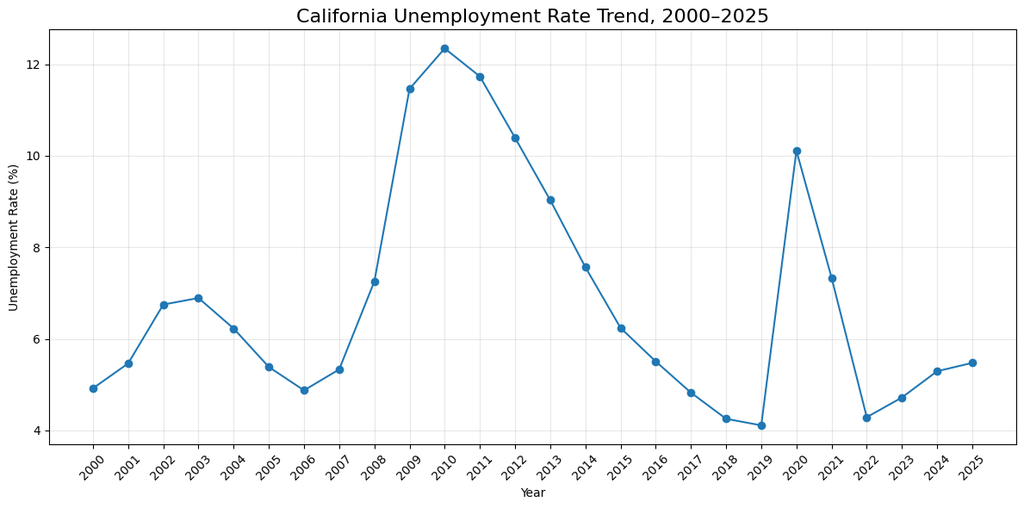

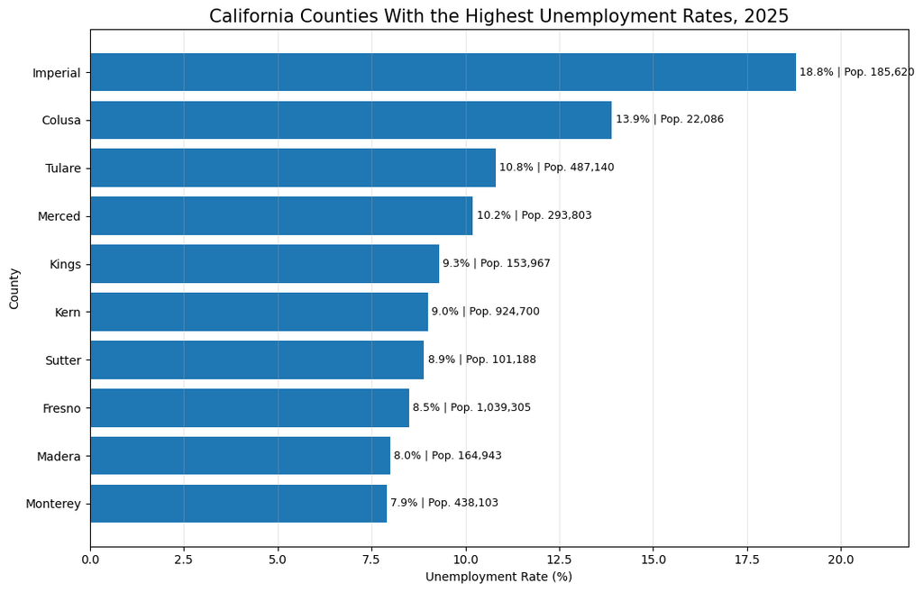

```python
# VISUALIZATION 1
# Stakeholder: California state policymakers and economic planners
# Purpose: Show the statewide unemployment trend over time.

statewide_trend = (
    combined_data
    .groupby("year")
    .agg({
        "Labor Force": "sum",
        "Unemployment": "sum"
    })
    .reset_index()
)

# Calculate a weighted statewide unemployment rate.
statewide_trend["Statewide Unemployment Rate"] = (
    statewide_trend["Unemployment"] /
    statewide_trend["Labor Force"] * 100
)

plt.figure(figsize=(12, 6))

plt.plot(
    statewide_trend["year"],
    statewide_trend["Statewide Unemployment Rate"],
    marker="o"
)

plt.title(
    "California Unemployment Rate Trend, 2000–2025",
    fontsize=16
)
plt.xlabel("Year")
plt.ylabel("Unemployment Rate (%)")
plt.grid(alpha=0.3)
plt.xticks(statewide_trend["year"], rotation=45)

plt.tight_layout()
plt.show()


# VISUALIZATION 2
# Stakeholder: County and local workforce development officials
# Purpose: Identify counties with the highest unemployment rates
# in the most recent year and show their population sizes.

latest_year = combined_data["year"].max()

latest_data = combined_data[
    combined_data["year"] == latest_year
].copy()

top_unemployment = (
    latest_data
    .sort_values("Unemployment Rate", ascending=False)
    .head(10)
    .sort_values("Unemployment Rate")
)

plt.figure(figsize=(11, 7))

bars = plt.barh(
    top_unemployment["county_lhj"],
    top_unemployment["Unemployment Rate"]
)

plt.title(
    f"California Counties With the Highest Unemployment Rates, {latest_year}",
    fontsize=15
)
plt.xlabel("Unemployment Rate (%)")
plt.ylabel("County")

# Add unemployment rate and population information to each bar.
for bar, rate, population in zip(
    bars,
    top_unemployment["Unemployment Rate"],
    top_unemployment["population"]
):
    plt.text(
        bar.get_width() + 0.1,
        bar.get_y() + bar.get_height() / 2,
        f"{rate:.1f}% | Pop. {population:,.0f}",
        va="center",
        fontsize=9
    )

plt.xlim(
    0,
    top_unemployment["Unemployment Rate"].max() + 3
)

plt.grid(axis="x", alpha=0.3)
plt.tight_layout()
plt.show()
```

Key Insights

The integrated data shows that California's unemployment rate changed substantially between 2000 and 2025. The statewide trend shows increased unemployment during the early 2000s, a major rise during the Great Recession that peaked around 2010, and another sharp increase in 2020. Unemployment then declined considerably before beginning to rise again in the most recent years.

At the county level, unemployment conditions vary considerably. In 2025, Imperial County had the highest unemployment rate among California counties, followed by Colusa and Tulare Counties. Population provides additional context because counties with similar unemployment rates may represent very different numbers of residents. Together, the visualizations provide both a broad view of California's labor market and a more detailed view of the counties experiencing the greatest unemployment challenges.